# Scenarios EFRE-Study

Author

Jule Schilling

Published

July 23, 2026

In this document: Hypotheses testing.

## Main Scenarios

## Hypothesis 1

**Click to expand.**

H1: Higher trait values in depression are related to withdrawal behavior in automated work situations.

**–> H1 was supported across all scenarios.**

**Depression**

SC06,SC12,SC13,SC14,SC15

_01 … ziehe ich mich zurück und warte wie sich die Situation entwickelt.

_02 … denke ich, dass die Aufgabenerfüllung sowieso nichts bringt.

_08 … bin ich mir sicher, dass ich die Aufgabe erfüllen kann. (R)

_04 … habe ich die Energie, um die Aufgabe anzugehen. (R)

#### Scenario 1

Scenario 1: Depression Items

| Variable | M | SD | Correlations 1 | Correlations 2 | Correlations 3 | Correlations 4 | Correlations 5 | Correlations 6 | Correlations 7 |
| --- | --- | --- | --- | --- | --- | --- | --- | --- | --- |
| 1. SC06_01 | 23.57 | 21.66 |  |  |  |  |  |  |  |
| 2. SC06_02 | 14.80 | 14.60 | .53 |  |  |  |  |  |  |
| 3. SC06_08 | 28.20 | 19.20 | .40 | .37 |  |  |  |  |  |
| 4. SC06_04 | 28.65 | 20.57 | .38 | .44 | .69 |  |  |  |  |
| 5. depression | 1.82 | 0.53 | .20 | .20 | .18 | .25 |  |  |  |
| 6. psychopathy | 2.83 | 1.62 | .08 | .05 | .08 | .02 | .03 |  |  |
| 7. trust_automation_all | 3.55 | 0.65 | -.25 | -.35 | -.34 | -.39 | -.21 | .03 |  |

Note:  
Scale: 1 - 100.

#### Scenario 2

Scenario 2: Depression Items

| Variable | M | SD | Correlations 1 | Correlations 2 | Correlations 3 | Correlations 4 | Correlations 5 |
| --- | --- | --- | --- | --- | --- | --- | --- |
| 1. SC12_01 | 19.73 | 23.61 |  |  |  |  |  |
| 2. SC12_02 | 25.33 | 26.39 | .55 |  |  |  |  |
| 3. SC12_08 | 35.93 | 23.42 | .52 | .42 |  |  |  |
| 4. SC12_04 | 38.12 | 26.23 | .56 | .50 | .75 |  |  |
| 5. depression | 1.82 | 0.53 | .13 | .15 | .23 | .23 |  |

Note:  
Scale: 1 - 100.

#### Scenario 3

Scenario 3: Depression Items

| Variable | M | SD | Correlations 1 | Correlations 2 | Correlations 3 | Correlations 4 | Correlations 5 |
| --- | --- | --- | --- | --- | --- | --- | --- |
| 1. SC13_01 | 19.42 | 22.27 |  |  |  |  |  |
| 2. SC13_02 | 16.21 | 18.12 | .47 |  |  |  |  |
| 3. SC13_08 | 26.54 | 19.54 | .45 | .36 |  |  |  |
| 4. SC13_04 | 27.14 | 21.53 | .50 | .39 | .75 |  |  |
| 5. depression | 1.82 | 0.53 | .22 | .16 | .18 | .24 |  |

Note:  
Scale: 1 - 100.

#### Scenario 4

Scenario 4: Depression Items

| Variable | M | SD | Correlations 1 | Correlations 2 | Correlations 3 | Correlations 4 | Correlations 5 |
| --- | --- | --- | --- | --- | --- | --- | --- |
| 1. SC14_01 | 22.89 | 25.69 |  |  |  |  |  |
| 2. SC14_02 | 15.03 | 17.48 | .63 |  |  |  |  |
| 3. SC14_08 | 25.71 | 19.38 | .49 | .50 |  |  |  |
| 4. SC14_04 | 26.58 | 20.45 | .45 | .48 | .83 |  |  |
| 5. depression | 1.82 | 0.53 | .17 | .17 | .24 | .24 |  |

Note:  
Scale: 1 - 100.

#### Scenario 5

Scenario 5: Depression Items

| Variable | M | SD | Correlations 1 | Correlations 2 | Correlations 3 | Correlations 4 | Correlations 5 |
| --- | --- | --- | --- | --- | --- | --- | --- |
| 1. SC15_01 | 21.17 | 21.57 |  |  |  |  |  |
| 2. SC15_02 | 21.71 | 22.92 | .53 |  |  |  |  |
| 3. SC15_08 | 32.90 | 22.05 | .39 | .39 |  |  |  |
| 4. SC15_04 | 31.92 | 22.02 | .46 | .50 | .74 |  |  |
| 5. depression | 1.82 | 0.53 | .20 | .16 | .19 | .20 |  |

Note:  
Scale: 1 - 100.

## Hypothesis 2

**Click to expand.**

H2: Higher trait values in psychopathy are related to selfish and less empathic behavior in automated work situations.

**–> H2 was partly supported.**

**Psychopathy**

SC07,SC16,SC17,SC18,SC19

_09 … täusche ich vor, für die Aufgabe zu beschäftigt zu sein.

_10 … versuche ich möglichst viele Vorteile für andere Mitarbeitende herauszuholen. (R)

_11 … sind mir die Befindlichkeiten anderer Mitarbeitenden wichtig.(R)

_12 … kann ich auch mal harte Entscheidungen treffen, die andere Mitarbeitende nicht fällen würden.

#### Scenario 1

Scenario 1: Psychopathy Items

| Variable | M | SD | Correlations 1 | Correlations 2 | Correlations 3 | Correlations 4 | Correlations 5 | Correlations 6 | Correlations 7 |
| --- | --- | --- | --- | --- | --- | --- | --- | --- | --- |
| 1. SC07_09 | 16.52 | 17.94 |  |  |  |  |  |  |  |
| 2. SC07_10 | 28.58 | 22.79 | .16 |  |  |  |  |  |  |
| 3. SC07_11 | 26.69 | 19.96 | .18 | .58 |  |  |  |  |  |
| 4. SC07_12 | 59.37 | 21.31 | -.19 | -.14 | .00 |  |  |  |  |
| 5. psychopathy | 2.83 | 1.62 | .11 | .05 | .16 | .13 |  |  |  |
| 6. depression | 1.82 | 0.53 | .20 | .08 | .06 | -.10 | .03 |  |  |
| 7. trust_automation_all | 3.55 | 0.65 | -.19 | -.01 | .08 | .29 | .03 | -.21 |  |

Note:  
Scale: 1 - 100.

#### Scenario 2

Scenario 2: Psychopathy Items

| Variable | M | SD | Correlations 1 | Correlations 2 | Correlations 3 | Correlations 4 | Correlations 5 | Correlations 6 | Correlations 7 |
| --- | --- | --- | --- | --- | --- | --- | --- | --- | --- |
| 1. SC16_09 | 22.13 | 25.06 |  |  |  |  |  |  |  |
| 2. SC16_10 | 27.78 | 25.97 | .19 |  |  |  |  |  |  |
| 3. SC16_11 | 20.95 | 21.02 | .20 | .63 |  |  |  |  |  |
| 4. SC16_12 | 56.68 | 25.19 | -.27 | -.09 | -.06 |  |  |  |  |
| 5. psychopathy | 2.83 | 1.62 | .07 | .06 | .18 | -.07 |  |  |  |
| 6. depression | 1.82 | 0.53 | .16 | .06 | .10 | -.12 | .03 |  |  |
| 7. trust_automation_all | 3.55 | 0.65 | -.20 | -.00 | .03 | .26 | .03 | -.21 |  |

Note:  
Scale: 1 - 100.

#### Scenario 3

Scenario 3: Psychopathy Items

| Variable | M | SD | Correlations 1 | Correlations 2 | Correlations 3 | Correlations 4 | Correlations 5 | Correlations 6 | Correlations 7 |
| --- | --- | --- | --- | --- | --- | --- | --- | --- | --- |
| 1. SC17_09 | 16.04 | 19.34 |  |  |  |  |  |  |  |
| 2. SC17_10 | 33.39 | 27.05 | .05 |  |  |  |  |  |  |
| 3. SC17_11 | 32.24 | 24.73 | .04 | .72 |  |  |  |  |  |
| 4. SC17_12 | 61.03 | 24.68 | -.26 | -.17 | -.05 |  |  |  |  |
| 5. psychopathy | 2.83 | 1.62 | .03 | .10 | .20 | .13 |  |  |  |
| 6. depression | 1.82 | 0.53 | .20 | .06 | .05 | -.16 | .03 |  |  |
| 7. trust_automation_all | 3.55 | 0.65 | -.26 | .05 | .08 | .31 | .03 | -.21 |  |

Note:  
Scale: 1 - 100.

#### Scenario 4

Scenario 4: Psychopathy Items

| Variable | M | SD | Correlations 1 | Correlations 2 | Correlations 3 | Correlations 4 | Correlations 5 | Correlations 6 | Correlations 7 |
| --- | --- | --- | --- | --- | --- | --- | --- | --- | --- |
| 1. SC18_09 | 16.66 | 20.06 |  |  |  |  |  |  |  |
| 2. SC18_10 | 31.53 | 26.90 | .20 |  |  |  |  |  |  |
| 3. SC18_11 | 31.56 | 24.87 | .14 | .71 |  |  |  |  |  |
| 4. SC18_12 | 59.32 | 25.15 | -.22 | -.25 | -.15 |  |  |  |  |
| 5. psychopathy | 2.83 | 1.62 | .15 | .12 | .20 | .02 |  |  |  |
| 6. depression | 1.82 | 0.53 | .15 | .01 | -.03 | -.16 | .03 |  |  |
| 7. trust_automation_all | 3.55 | 0.65 | -.22 | -.05 | -.01 | .28 | .03 | -.21 |  |

Note:  
Scale: 1 - 100.

#### Scenario 5

Scenario 5: Psychopathy Items

| Variable | M | SD | Correlations 1 | Correlations 2 | Correlations 3 | Correlations 4 | Correlations 5 | Correlations 6 | Correlations 7 |
| --- | --- | --- | --- | --- | --- | --- | --- | --- | --- |
| 1. SC19_09 | 17.16 | 19.51 |  |  |  |  |  |  |  |
| 2. SC19_10 | 32.68 | 25.59 | .23 |  |  |  |  |  |  |
| 3. SC19_11 | 28.95 | 21.77 | .27 | .72 |  |  |  |  |  |
| 4. SC19_12 | 57.87 | 24.28 | -.19 | -.14 | -.13 |  |  |  |  |
| 5. psychopathy | 2.83 | 1.62 | .12 | .10 | .21 | -.00 |  |  |  |
| 6. depression | 1.82 | 0.53 | .22 | .09 | .09 | -.12 | .03 |  |  |
| 7. trust_automation_all | 3.55 | 0.65 | -.25 | .01 | .02 | .29 | .03 | -.21 |  |

Note:  
Scale: 1 - 100.

## Hypothesis 3

**Click to expand.**

H3: Higher trait values in trust in automation are related to more trusting behavior in automated work situations.

**–> H3 was supported across all scenarios.**

**Trust**

SC08,SC20,SC21,SC22,SC23

_13 … betrachte ich die Automatisierung als eine Art hilfreichen Partner.

_14 … ist die Rolle der Automatisierung mit Skepsis zu betrachten. (R)

_15 … habe ich Angst vor der Automatisierung. (R)

_16 … vertraue ich auf die Automatisierung.

#### Scenario 1

Scenario 1: Trust Items

| Variable | M | SD | Correlations 1 | Correlations 2 | Correlations 3 | Correlations 4 | Correlations 5 | Correlations 6 | Correlations 7 | Correlations 8 |
| --- | --- | --- | --- | --- | --- | --- | --- | --- | --- | --- |
| 1. SC08_13 | 84.32 | 16.18 |  |  |  |  |  |  |  |  |
| 2. SC08_14 | 65.84 | 24.90 | .42 |  |  |  |  |  |  |  |
| 3. SC08_15 | 77.69 | 22.72 | .39 | .50 |  |  |  |  |  |  |
| 4. SC08_16 | 64.96 | 21.21 | .52 | .50 | .36 |  |  |  |  |  |
| 5. trust_automation_all | 3.55 | 0.65 | .50 | .41 | .50 | .52 |  |  |  |  |
| 6. trust_humans | 2.84 | 0.85 | .05 | .14 | .18 | .10 | .17 |  |  |  |
| 7. depression | 1.82 | 0.53 | -.14 | -.05 | -.13 | -.14 | -.21 | -.32 |  |  |
| 8. psychopathy | 2.83 | 1.62 | -.04 | -.05 | -.05 | .05 | .03 | -.24 | .03 |  |

Note:  
Scale: 1 - 100.

#### Scenario 2

Scenario 2: Trust Items

| Variable | M | SD | Correlations 1 | Correlations 2 | Correlations 3 | Correlations 4 | Correlations 5 | Correlations 6 | Correlations 7 | Correlations 8 |
| --- | --- | --- | --- | --- | --- | --- | --- | --- | --- | --- |
| 1. SC20_13 | 36.08 | 30.42 |  |  |  |  |  |  |  |  |
| 2. SC20_14 | 33.50 | 27.43 | .69 |  |  |  |  |  |  |  |
| 3. SC20_15 | 66.56 | 28.32 | .42 | .48 |  |  |  |  |  |  |
| 4. SC20_16 | 32.26 | 26.85 | .79 | .69 | .39 |  |  |  |  |  |
| 5. trust_automation_all | 3.55 | 0.65 | .33 | .34 | .34 | .34 |  |  |  |  |
| 6. trust_humans | 2.84 | 0.85 | -.03 | -.01 | .11 | -.04 | .17 |  |  |  |
| 7. depression | 1.82 | 0.53 | -.13 | -.11 | -.10 | -.12 | -.21 | -.32 |  |  |
| 8. psychopathy | 2.83 | 1.62 | .11 | .08 | -.02 | .13 | .03 | -.24 | .03 |  |

Note:  
Scale: 1 - 100.

#### Scenario 3

Scenario 3: Trust Items

| Variable | M | SD | Correlations 1 | Correlations 2 | Correlations 3 | Correlations 4 | Correlations 5 | Correlations 6 | Correlations 7 | Correlations 8 |
| --- | --- | --- | --- | --- | --- | --- | --- | --- | --- | --- |
| 1. SC21_13 | 81.61 | 19.22 |  |  |  |  |  |  |  |  |
| 2. SC21_14 | 65.64 | 26.28 | .49 |  |  |  |  |  |  |  |
| 3. SC21_15 | 77.55 | 22.92 | .59 | .54 |  |  |  |  |  |  |
| 4. SC21_16 | 65.28 | 21.56 | .62 | .65 | .49 |  |  |  |  |  |
| 5. trust_automation_all | 3.55 | 0.65 | .44 | .40 | .43 | .51 |  |  |  |  |
| 6. trust_humans | 2.84 | 0.85 | .01 | .15 | .13 | .10 | .17 |  |  |  |
| 7. depression | 1.82 | 0.53 | -.13 | -.14 | -.16 | -.20 | -.21 | -.32 |  |  |
| 8. psychopathy | 2.83 | 1.62 | .02 | -.05 | .01 | -.03 | .03 | -.24 | .03 |  |

Note:  
Scale: 1 - 100.

#### Scenario 4

Scenario 4: Trust Items

| Variable | M | SD | Correlations 1 | Correlations 2 | Correlations 3 | Correlations 4 | Correlations 5 | Correlations 6 | Correlations 7 | Correlations 8 |
| --- | --- | --- | --- | --- | --- | --- | --- | --- | --- | --- |
| 1. SC22_13 | 84.68 | 18.45 |  |  |  |  |  |  |  |  |
| 2. SC22_14 | 73.03 | 23.93 | .56 |  |  |  |  |  |  |  |
| 3. SC22_15 | 83.26 | 19.80 | .59 | .63 |  |  |  |  |  |  |
| 4. SC22_16 | 69.16 | 22.49 | .66 | .60 | .52 |  |  |  |  |  |
| 5. trust_automation_all | 3.55 | 0.65 | .30 | .35 | .39 | .42 |  |  |  |  |
| 6. trust_humans | 2.84 | 0.85 | .02 | .17 | .15 | .13 | .17 |  |  |  |
| 7. depression | 1.82 | 0.53 | -.15 | -.12 | -.11 | -.15 | -.21 | -.32 |  |  |
| 8. psychopathy | 2.83 | 1.62 | .02 | -.04 | -.10 | .03 | .03 | -.24 | .03 |  |

Note:  
Scale: 1 - 100.

#### Scenario 5

Scenario 5: Trust Items

| Variable | M | SD | Correlations 1 | Correlations 2 | Correlations 3 | Correlations 4 | Correlations 5 | Correlations 6 | Correlations 7 | Correlations 8 |
| --- | --- | --- | --- | --- | --- | --- | --- | --- | --- | --- |
| 1. SC23_13 | 66.61 | 25.50 |  |  |  |  |  |  |  |  |
| 2. SC23_14 | 52.24 | 27.20 | .61 |  |  |  |  |  |  |  |
| 3. SC23_15 | 78.18 | 22.09 | .39 | .46 |  |  |  |  |  |  |
| 4. SC23_16 | 51.24 | 23.74 | .59 | .60 | .33 |  |  |  |  |  |
| 5. trust_automation_all | 3.55 | 0.65 | .35 | .35 | .42 | .45 |  |  |  |  |
| 6. trust_humans | 2.84 | 0.85 | -.09 | .04 | .22 | .05 | .17 |  |  |  |
| 7. depression | 1.82 | 0.53 | -.12 | -.13 | -.18 | -.15 | -.21 | -.32 |  |  |
| 8. psychopathy | 2.83 | 1.62 | .07 | -.03 | -.10 | .07 | .03 | -.24 | .03 |  |

Note:  
Scale: 1 - 100.

## Leadership scenarios

## Leader’s perspective: coercive behavior

## Hypothesis 4

**Click to expand.**

H4: Higher trait values in psychopathy are associated with more coercive behavior.

Scenario Leadership: Coersive Items

| Variable | M | SD | Correlations 1 | Correlations 2 | Correlations 3 | Correlations 4 |
| --- | --- | --- | --- | --- | --- | --- |
| 1. SL04_08 | 24.86 | 23.76 |  |  |  |  |
| 2. SL04_04 | 29.00 | 26.97 | .42 |  |  |  |
| 3. SL04_10 | 13.62 | 18.63 | .17 | .30 |  |  |
| 4. psychopathy | 2.83 | 1.62 | .15 | .24 | .27 |  |

Note:  
Scale: 1 - 100.

## Leader’s perspective: cooperative behavior

## Hypothesis 5,6,7,8

**Click to expand.**

H5: Higher trait values in trust are associated with more cooperative behavior.

H6: Higher trait values in prosocial tendencies are associated with more cooperative behavior.

H7: Higher trait values in agreeableness are associated with more cooperative behavior.

H8: Higher trait values in self-efficacy are associated with more cooperative behavior.

–> partly supported; mostly unexpected effects for item 3 “…stelle ich eine Bonuszahlung in Aussicht, wenn die Zielvorgaben erfüllt werden.”

Scenario Leadership: Cooperative Items

| Variable | M | SD | Correlations 1 | Correlations 2 | Correlations 3 | Correlations 4 | Correlations 5 | Correlations 6 | Correlations 7 | Correlations 8 | Correlations 9 |
| --- | --- | --- | --- | --- | --- | --- | --- | --- | --- | --- | --- |
| 1. SL04_01 | 83.00 | 18.83 |  |  |  |  |  |  |  |  |  |
| 2. SL04_02 | 86.54 | 15.80 | .34 |  |  |  |  |  |  |  |  |
| 3. SL04_09 | 75.45 | 22.88 | -.04 | .19 |  |  |  |  |  |  |  |
| 4. trust_automation_all | 3.55 | 0.65 | .17 | .12 | -.03 |  |  |  |  |  |  |
| 5. trust_humans | 2.84 | 0.85 | .09 | .16 | -.00 | .17 |  |  |  |  |  |
| 6. proso_tend | 4.08 | 0.61 | .26 | .17 | .08 | .03 | .19 |  |  |  |  |
| 7. agreeablenesss | 3.24 | 0.74 | .10 | .11 | .14 | .07 | .57 | .29 |  |  |  |
| 8. self_efficacy | 4.27 | 0.93 | .13 | .15 | -.04 | .31 | .25 | .04 | .12 |  |  |
| 9. psychopathy | 2.83 | 1.62 | -.22 | -.18 | -.13 | .03 | -.24 | -.42 | -.40 | .03 |  |

Note:  
Scale: 1 - 100.

## Order effect

## Hypothesis 9

**Click to expand.**

H9: Cooperative behavior is higher when participants are first presented with the employees’ perspective (i.e., employees’ perspective first) than if they are first presented with the leaders’ perspective (i.e., leaders’ perspective first)

Employee first - Leader first; positive values indicate that there is more cooperative behavior when the employee scenario is presented first

Expected “empathy effect” for item: “Suche ich das Gespräch mit den Mitarbeitenden, wann die geleisteten Überstunden wieder abgebaut werden können.”; no effect for other items –> Hypothesis partly supported

```
    Welch Two Sample t-test

data:  SL04_01 by order_leadership
t = 4.7439, df = 295.39, p-value = 3.269e-06
alternative hypothesis: true difference in means between group employee first and group leader first is not equal to 0
95 percent confidence interval:
  5.453858 13.187154
sample estimates:
mean in group employee first   mean in group leader first
                    87.54144                     78.22093
```

```
Cohen's d |       95% CI
------------------------
0.51      | [0.30, 0.72]

- Estimated using pooled SD.
```

```
    Welch Two Sample t-test

data:  SL04_02 by order_leadership
t = 1.7277, df = 336.47, p-value = 0.08496
alternative hypothesis: true difference in means between group employee first and group leader first is not equal to 0
95 percent confidence interval:
 -0.4030317  6.2216106
sample estimates:
mean in group employee first   mean in group leader first
                    87.95580                     85.04651
```

```
Cohen's d |        95% CI
-------------------------
0.18      | [-0.02, 0.39]

- Estimated using pooled SD.
```

```
    Welch Two Sample t-test

data:  SL04_09 by order_leadership
t = -0.54271, df = 350.97, p-value = 0.5877
alternative hypothesis: true difference in means between group employee first and group leader first is not equal to 0
95 percent confidence interval:
 -6.109469  3.466915
sample estimates:
mean in group employee first   mean in group leader first
                    74.80663                     76.12791
```

```
Cohen's d |        95% CI
-------------------------
-0.06     | [-0.27, 0.15]

- Estimated using pooled SD.
```

## Hypothesis 10

**Click to expand.**

H10: Coersive behavior is lower when participants are first presented with the employees’ perspective than if they are first presented with the leaders’ perspective

Employee first - Leader first; positive values indicate that there is more coersive behavior when the employee scenario is presented first

Expected “empathy effect” for all items. Hypothesis was supported for all items.

```
    Welch Two Sample t-test

data:  SL04_08 by order_leadership
t = -2.3305, df = 339.99, p-value = 0.02037
alternative hypothesis: true difference in means between group employee first and group leader first is not equal to 0
95 percent confidence interval:
 -10.8384440  -0.9167917
sample estimates:
mean in group employee first   mean in group leader first
                    21.99448                     27.87209
```

```
Cohen's d |         95% CI
--------------------------
-0.25     | [-0.46, -0.04]

- Estimated using pooled SD.
```

```
    Welch Two Sample t-test

data:  SL04_04 by order_leadership
t = -2.2282, df = 343.52, p-value = 0.02651
alternative hypothesis: true difference in means between group employee first and group leader first is not equal to 0
95 percent confidence interval:
 -12.0078511  -0.7480271
sample estimates:
mean in group employee first   mean in group leader first
                    25.88950                     32.26744
```

```
Cohen's d |         95% CI
--------------------------
-0.24     | [-0.45, -0.03]

- Estimated using pooled SD.
```

```
    Welch Two Sample t-test

data:  SL04_10 by order_leadership
t = -2.7775, df = 316.61, p-value = 0.005805
alternative hypothesis: true difference in means between group employee first and group leader first is not equal to 0
95 percent confidence interval:
 -9.390593 -1.603047
sample estimates:
mean in group employee first   mean in group leader first
                    10.93923                     16.43605
```

```
Cohen's d |         95% CI
--------------------------
-0.30     | [-0.51, -0.09]

- Estimated using pooled SD.
```

## Employee’s perspective: reactant behavior

## Hypothesis 11, 14, 16

**Click to expand.**

H11: Lower trait values in agreeableness are associated with more reactant behavior.

H14: Higher trait values in psychopathy are associated with more reactant behavior.

H16: Higher trait values in depression are associated with more reactant behavior.

–> agreeableness not supported; depression and psychopathy partly supported.

Scenario Employsee: Reactant Items

| Variable | M | SD | Correlations 1 | Correlations 2 | Correlations 3 | Correlations 4 | Correlations 5 | Correlations 6 |
| --- | --- | --- | --- | --- | --- | --- | --- | --- |
| 1. SL05_01 | 24.06 | 22.30 |  |  |  |  |  |  |
| 2. SL05_05 | 38.53 | 27.91 | .27 |  |  |  |  |  |
| 3. SL05_06 | 6.59 | 12.09 | .20 | .25 |  |  |  |  |
| 4. agreeablenesss | 3.24 | 0.74 | .02 | -.06 | -.06 |  |  |  |
| 5. psychopathy | 2.83 | 1.62 | .06 | .01 | .24 | -.40 |  |  |
| 6. depression | 1.82 | 0.53 | .11 | .10 | .10 | -.25 | .03 |  |

Note:  
Scale: 1 - 100.

## Employee’s perspective: cooperative behavior

## Hypothesis 12, 13, 15

**Click to expand.**

H12: Higher trait values in conscientiousness are associated with more cooperative behavior.

H13: Higher trait values in agreeableness are associated with more cooperative behavior.

H15: Higher trait values in trust are associated with more cooperative behavior.

| Variable | M | SD | Correlations 1 | Correlations 2 | Correlations 3 | Correlations 4 | Correlations 5 | Correlations 6 | Correlations 7 |
| --- | --- | --- | --- | --- | --- | --- | --- | --- | --- |
| 1. SL05_02 | 84.59 | 16.15 |  |  |  |  |  |  |  |
| 2. SL05_03 | 84.44 | 14.73 | .38 |  |  |  |  |  |  |
| 3. SL05_04 | 70.55 | 24.80 | -.02 | .35 |  |  |  |  |  |
| 4. conscientiousness | 3.75 | 0.67 | .33 | .15 | -.07 |  |  |  |  |
| 5. agreeablenesss | 3.24 | 0.74 | .02 | .01 | -.01 | .12 |  |  |  |
| 6. trust_humans | 2.84 | 0.85 | .07 | .06 | .00 | .04 | .57 |  |  |
| 7. trust_automation_all | 3.55 | 0.65 | .33 | .04 | -.10 | .14 | .07 | .17 |  |

Note:  
Scale: 1 - 100.

## Order effect

## Hypothesis 17

**Click to expand.**

H17: Cooperative behavior is higher when participants are first presented with the leaders’ perspective than if they are first presented with the employees’ perspective.

Employee first - Leader first; positive values indicate that there is more cooperative behavior when the employee scenario is presented first

Expected “empathy effect” for none of the items. However d =.2 for item “suche ich das Gespräch mit der Führungskraft, um über die hohe Arbeitsbelastung zu sprechen.”

–> Hypothesis not supported

```
    Welch Two Sample t-test

data:  SL05_02 by order_leadership
t = 0.51735, df = 349.87, p-value = 0.6052
alternative hypothesis: true difference in means between group employee first and group leader first is not equal to 0
95 percent confidence interval:
 -2.488886  4.265643
sample estimates:
mean in group employee first   mean in group leader first
                    85.02210                     84.13372
```

```
Cohen's d |        95% CI
-------------------------
0.05      | [-0.15, 0.26]

- Estimated using pooled SD.
```

```
    Welch Two Sample t-test

data:  SL05_03 by order_leadership
t = -0.32978, df = 347.21, p-value = 0.7418
alternative hypothesis: true difference in means between group employee first and group leader first is not equal to 0
95 percent confidence interval:
 -3.593013  2.561148
sample estimates:
mean in group employee first   mean in group leader first
                    84.19337                     84.70930
```

```
Cohen's d |        95% CI
-------------------------
-0.03     | [-0.24, 0.17]

- Estimated using pooled SD.
```

```
    Welch Two Sample t-test

data:  SL05_04 by order_leadership
t = -1.8632, df = 348.72, p-value = 0.06328
alternative hypothesis: true difference in means between group employee first and group leader first is not equal to 0
95 percent confidence interval:
 -10.0454544   0.2717168
sample estimates:
mean in group employee first   mean in group leader first
                    68.17127                     73.05814
```

```
Cohen's d |        95% CI
-------------------------
-0.20     | [-0.41, 0.01]

- Estimated using pooled SD.
```

## Hypothesis 18

**Click to expand.**

H18: Reactant behavior is lower when participants are first presented with the leaders’ perspective than if they are first presented with the employees’ perspective.

Employee first - Leader first; positive values indicate that there is more reactant behavior when the employee scenario is presented first

More reactant behavior when first presented with leadership scenario for item: “äußere ich meinen Unmut über die Situation beim Betriebsrat”

–> hypothesis not supported

```
    Welch Two Sample t-test

data:  SL05_01 by order_leadership
t = 1.0844, df = 348.37, p-value = 0.279
alternative hypothesis: true difference in means between group employee first and group leader first is not equal to 0
95 percent confidence interval:
 -2.087571  7.217984
sample estimates:
mean in group employee first   mean in group leader first
                    25.30939                     22.74419
```

```
Cohen's d |        95% CI
-------------------------
0.12      | [-0.09, 0.32]

- Estimated using pooled SD.
```

```
    Welch Two Sample t-test

data:  SL05_05 by order_leadership
t = -2.8727, df = 346.58, p-value = 0.00432
alternative hypothesis: true difference in means between group employee first and group leader first is not equal to 0
95 percent confidence interval:
 -14.257670  -2.668836
sample estimates:
mean in group employee first   mean in group leader first
                    34.40884                     42.87209
```

```
Cohen's d |         95% CI
--------------------------
-0.31     | [-0.52, -0.10]

- Estimated using pooled SD.
```

```
    Welch Two Sample t-test

data:  SL05_06 by order_leadership
t = -1.1659, df = 289.47, p-value = 0.2446
alternative hypothesis: true difference in means between group employee first and group leader first is not equal to 0
95 percent confidence interval:
 -4.074599  1.043120
sample estimates:
mean in group employee first   mean in group leader first
                    5.856354                     7.372093
```

```
Cohen's d |        95% CI
-------------------------
-0.13     | [-0.33, 0.08]

- Estimated using pooled SD.
```

## Interaction order effect with trait variables

## Leadership perspective

## Hypothesis 19

**Click to expand.**

H19: If psychopathy is low, the order effect of employees’ perspective first versus leaders’ perspective first on coersive behavior (H10) is higher than if psychopathy is high.

–> not supported

```
Anova Table (Type III tests)

Response: SL04_08
                                  Sum Sq  Df  F value    Pr(>F)
(Intercept)                       216115   1 393.6536 < 2.2e-16 ***
order_leadership                    2350   1   4.2800  0.039298 *
psychopathy_cent                    3920   1   7.1411  0.007887 **
order_leadership:psychopathy_cent     60   1   0.1099  0.740460
Residuals                         191600 349
---
Signif. codes:  0 '***' 0.001 '**' 0.01 '*' 0.05 '.' 0.1 ' ' 1
```

## Hypotheses 20,21,22

**Click to expand.**

H20: If trust is low, the order effect of employees’ perspective first versus leaders’ perspective first on cooperative behavior (H9) is higher than if trust is high.

H21: If prosocial tendencies are low, the order effect of employees’ perspective first versus leaders’ perspective first on cooperative behavior (H9) is higher than if prosocial tendencies are high.

H22: If agreeableness is low, the order effect of employees’ perspective first versus leaders’ perspective first on cooperative behavior (H9) is higher than if agreeableness is high.

–> all hypotheses not supported

```
Anova Table (Type III tests)

Response: SL04_01
                                 Sum Sq  Df   F value    Pr(>F)
(Intercept)                     2392074   1 7317.9803 < 2.2e-16 ***
order_leadership                   6438   1   19.6950  1.22e-05 ***
trust_all_cent                     2918   1    8.9270  0.003009 **
order_leadership:trust_all_cent     139   1    0.4254  0.514682
Residuals                        114080 349
---
Signif. codes:  0 '***' 0.001 '**' 0.01 '*' 0.05 '.' 0.1 ' ' 1
```

```
Anova Table (Type III tests)

Response: SL04_01
                                  Sum Sq  Df  F value    Pr(>F)
(Intercept)                      2417065   1 7745.107 < 2.2e-16 ***
order_leadership                    6527   1   20.914 6.682e-06 ***
proso_tend_cent                     7136   1   22.866 2.565e-06 ***
order_leadership:proso_tend_cent     952   1    3.050   0.08161 .
Residuals                         108915 349
---
Signif. codes:  0 '***' 0.001 '**' 0.01 '*' 0.05 '.' 0.1 ' ' 1
```

```
Anova Table (Type III tests)

Response: SL04_01
                                      Sum Sq  Df   F value    Pr(>F)
(Intercept)                          2415464   1 7259.1217 < 2.2e-16 ***
order_leadership                        7283   1   21.8861 4.144e-06 ***
agreeablenesss_cent                      992   1    2.9811   0.08513 .
order_leadership:agreeablenesss_cent      88   1    0.2636   0.60801
Residuals                             116129 349
---
Signif. codes:  0 '***' 0.001 '**' 0.01 '*' 0.05 '.' 0.1 ' ' 1
```

## Employee’s perspective

## Hypothesis 23

**Click to expand.**

H23: If psychopathy is low, the order effect of employees’ perspective first versus leaders’ perspective first on reactant behavior (18) is higher than if psychopathy is high.

```
Anova Table (Type III tests)

Response: SL05_01
                                  Sum Sq  Df  F value Pr(>F)
(Intercept)                       203171   1 409.0839 <2e-16 ***
order_leadership                     719   1   1.4486 0.2296
psychopathy_cent                     806   1   1.6227 0.2036
order_leadership:psychopathy_cent    350   1   0.7042 0.4020
Residuals                         173331 349
---
Signif. codes:  0 '***' 0.001 '**' 0.01 '*' 0.05 '.' 0.1 ' ' 1
```

## Hypotheses 24,25,26

**Click to expand.**

H24: If trust is low, the order effect of employees’ perspective first versus leaders’ perspective first on cooperative behavior (H17) is higher than if trust is high.

–> supported(?)

H25: If prosocial tendencies are low, the order effect of employees’ perspective first versus leaders’ perspective first on cooperative behavior (H17) is higher than if prosocial tendencies are high.

H26: If agreeableness is low, the order effect of employees’ perspective first versus leaders’ perspective first on cooperative behavior (H17) is higher than if agreeableness is high.

–> H25 & 26 not supported

```
Anova Table (Type III tests)

Response: SL05_02
                                 Sum Sq  Df    F value    Pr(>F)
(Intercept)                     2474986   1 10499.3445 < 2.2e-16 ***
order_leadership                      9   1     0.0380   0.84560
trust_all_cent                     8654   1    36.7107  3.55e-09 ***
order_leadership:trust_all_cent     934   1     3.9612   0.04734 *
Residuals                         82269 349
---
Signif. codes:  0 '***' 0.001 '**' 0.01 '*' 0.05 '.' 0.1 ' ' 1
```

```
Anova Table (Type III tests)

Response: SL05_02
                                 Sum Sq  Df    F value    Pr(>F)
(Intercept)                     2474986   1 10499.3445 < 2.2e-16 ***
order_leadership                      9   1     0.0380   0.84560
trust_all_cent                     8654   1    36.7107  3.55e-09 ***
order_leadership:trust_all_cent     934   1     3.9612   0.04734 *
Residuals                         82269 349
---
Signif. codes:  0 '***' 0.001 '**' 0.01 '*' 0.05 '.' 0.1 ' ' 1
```

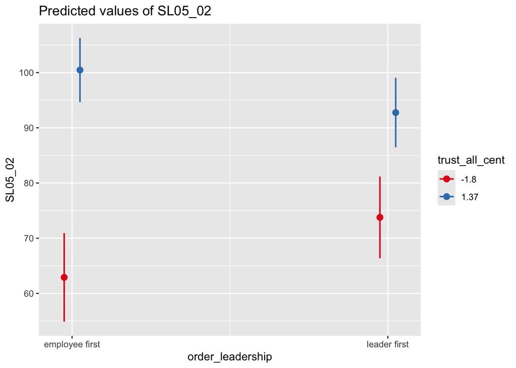

```
Anova Table (Type III tests)

Response: SL05_02
                                  Sum Sq  Df   F value Pr(>F)
(Intercept)                      2509653   1 9600.9589 <2e-16 ***
order_leadership                      43   1    0.1635 0.6862
proso_tend_cent                      545   1    2.0845 0.1497
order_leadership:proso_tend_cent       6   1    0.0232 0.8790
Residuals                          91227 349
---
Signif. codes:  0 '***' 0.001 '**' 0.01 '*' 0.05 '.' 0.1 ' ' 1
```

```
Anova Table (Type III tests)

Response: SL05_02
                                      Sum Sq  Df   F value Pr(>F)
(Intercept)                          2512350   1 9560.6289 <2e-16 ***
order_leadership                          63   1    0.2394 0.6250
agreeablenesss_cent                       40   1    0.1529 0.6960
order_leadership:agreeablenesss_cent      23   1    0.0881 0.7668
Residuals                              91710 349
---
Signif. codes:  0 '***' 0.001 '**' 0.01 '*' 0.05 '.' 0.1 ' ' 1
```